# Introduction to Statistics for Social Sciences using R

Modules 1–5: Data Hygiene to Linear Regression

Neena Abimbola Albarus

2026-10-13

# Course Roadmap

### Building Quantitative Social Science Skills

- **Module 1:** Workspace Setup, Data Hygiene & Filtering
- **Module 2:** Descriptive Statistics & Summary Tables
- **Module 3:** The Visual Workshop (`ggplot2` Gallery)
- **Module 4:** Correlation & Bivariate Analysis
- **Module 5:** Simple Linear Regression Models (OLS)

# Module 1: Workspace Infrastructure & Data Hygiene

## Why Data Hygiene Matters

Raw social science datasets (UN, World Bank, OWID) are designed for storage, not analysis.

### Common Raw Data Issues:

1. **Irrelevant Cases:** Thousands of extra territories outside our study.
2. **Messy Column Headers:** Spaces, capitals, and obscure codes (e.g., `` `Life expectancy at birth (historical)` ``).
3. **Data Types:** Numbers stored as text strings or missing values (`NA`).

## Data Hygiene Pipeline in R

```r
library(tidyverse)

# 1. Ingest raw OWID CSV data
life_df <- read_csv("/Users/yawdgyal/Desktop/R for github/Introduction-to-Statistics-for-Social-Sciences-using-R/data/life_expectancy_data.csv")

# 2. Isolate target variables and standardize names
# 3. Filter for 8 case-study nations (Post-1950)
social_df <- life_df %>%
  select(Entity, Code, Year, `Life expectancy`) %>%
  rename(
    country  = Entity,
    code     = Code,
    year     = Year,
    life_exp = `Life expectancy`
  ) %>%
  filter(
    country %in% c("Canada", "United States", "Spain", "Jamaica",
                   "Brazil", "India", "Nigeria", "South Africa") &
    year >= 1950
  )

head(social_df, 3)
```

```
# A tibble: 3 × 4
  country code   year life_exp
  <chr>   <chr> <dbl>    <dbl>
1 Brazil  BRA    1950     48.5
2 Brazil  BRA    1951     49.0
3 Brazil  BRA    1952     49.6
```

# Module 2: Descriptive Statistics & Summary Tables

## Central Tendency vs. Dispersion

Social science data often experiences exogenous shocks (wars, epidemics, recessions).

- **Central Tendency:**
  - **Mean (**$\bar{X}$): Sensitive to extreme outliers.
  - **Median:** Robust metric based on positional ranking (50th percentile).
- **Dispersion (Spread):**
  - **Standard Deviation (**$SD$): Average deviation from the mean.
  - **Interquartile Range (**$IQR$): Distance between 25th ($Q_1$) and 75th ($Q_3$) percentiles.

## Grouped Comparative Metrics

```r
country_stats <- social_df %>%
  group_by(country) %>%
  summarize(
    years      = n(),
    mean_exp   = round(mean(life_exp), 1),
    median_exp = round(median(life_exp), 1),
    sd_exp     = round(sd(life_exp), 1),
    iqr_exp    = round(IQR(life_exp), 1)
  ) %>%
  arrange(desc(mean_exp))

country_stats
```

```
# A tibble: 8 × 6
  country       years mean_exp median_exp sd_exp iqr_exp
  <chr>         <int>    <dbl>      <dbl>  <dbl>   <dbl>
1 Canada           74     76.2       76.6    4.3     7.8
2 Spain            74     75.7       76.8    5.7     8.9
3 United States    74     74.2       74.8    3.5     6.6
4 Jamaica          74     68.5       70.3    4.1     5.1
5 Brazil           74     63.9       64.6    8.5    15.1
6 South Africa     74     57.7       58.4    5.5     7.9
7 India            74     56.6       57.1    9.4    16.8
8 Nigeria          74     44.9       45.8    5.7    10.7
```

# Module 3: The Social Scientist’s Visual Workshop

## The Grammar of Graphics (`ggplot2`)

Plots are constructed systematically in layers:

1. **Data:** `social_df`
2. **Aesthetic Mapping (`aes`):** `x = year`, `y = life_exp`, `color = country`
3. **Geometries (`geom_*`):** `geom_line()`, `geom_boxplot()`, `geom_histogram()`
4. **Facets (`facet_wrap`):** Small multiples for comparative panels.

## Comparative Trends & Faceting

```r
ggplot(data = social_df, aes(x = year, y = life_exp)) +
  geom_line(color = "navy", linewidth = 0.8) +
  facet_wrap(~ country, ncol = 4) +
  labs(title = "Life Expectancy Trajectories (1950–Present)",
       x = "Year", y = "Life Expectancy (Years)") +
  theme_bw()
```

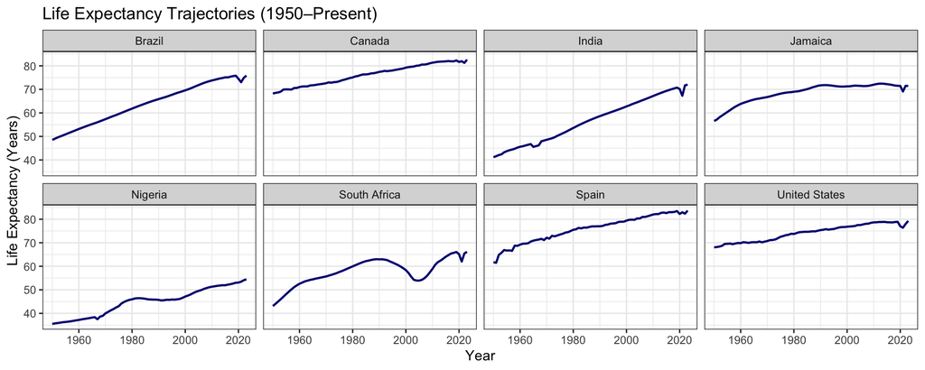

# Module 4: Bivariate Correlation Analysis

## Pearson’s Correlation Coefficient ($r$)

$$r = \frac{\sum (x_i - \bar{x})(y_i - \bar{y})}{\sqrt{\sum (x_i - \bar{x})^2 \sum (y_i - \bar{y})^2}}$$

- **Range:** $-1.0$ (perfect negative) to $+1.0$ (perfect positive).
- **Interpretation:**
  - Measures strength and direction of linear co-movement.
  - Testing $H_0: \rho = 0$ via `cor.test()`.

## Estimating Pooled Correlation

```r
# Hypothesis test for linear association
global_cor <- cor.test(social_df$year, social_df$life_exp, method = "pearson")

cat("Pearson r: ", round(global_cor$estimate, 3), "\n")
```

```
Pearson r:  0.457
```

```r
cat("p-value:   ", global_cor$p.value, "\n")
```

```
p-value:    7.469634e-32
```

# Module 5: Simple Linear Regression Models

## From Correlation to Regression

Regression converts association into a **predictive equation**:

$$\hat{Y}_i = \hat{\beta}_0 + \hat{\beta}_1 X_i$$

- $\hat{Y}_i$ (Outcome): Life Expectancy.
- $X_i$ (Predictor): Centered Year (`year_1950 = year - 1950`).
- $\hat{\beta}_0$ (Intercept): Expected baseline value of $Y$ when $X = 0$ (Year 1950).
- $\hat{\beta}_1$ (Slope): Estimated average change in $Y$ per 1-unit increase in $X$.

## OLS Model Estimation in R

```r
# Center year at 1950 for baseline interpretability
social_df <- social_df %>% mutate(year_1950 = year - 1950)

# Estimate OLS model
ols_model <- lm(life_exp ~ year_1950, data = social_df)
summary(ols_model)$coefficients
```

```
              Estimate Std. Error  t value      Pr(>|t|)
(Intercept) 55.2845418 0.87558084 63.14042 1.213976e-264
year_1950    0.2582244 0.02070388 12.47227  7.469634e-32
```

## Visualizing OLS Regression Fit

```r
ggplot(data = social_df, aes(x = year, y = life_exp)) +
  geom_point(aes(color = country), alpha = 0.4) +
  geom_smooth(method = "lm", color = "black", linewidth = 1) +
  labs(title = "OLS Model Fit: Life Expectancy ~ Time",
       x = "Year", y = "Life Expectancy (Years)") +
  theme_minimal()
```

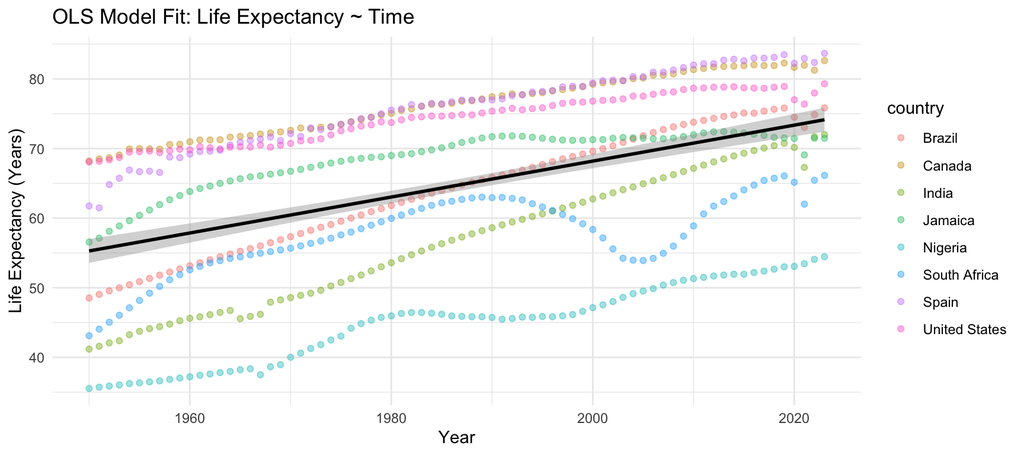

# Summary & Next Steps

### Coming Up in Module 6:

- **Multiple Linear Regression (MLR):** Adding economic indicators (GDP per capita) as control variables!